# SPACESHIP TITANIC

## IMPORTING LIBRARIES

```python
import pandas as pd
import numpy as np
import matplotlib.pyplot as pp
import seaborn as sb
import datasist as ds
%matplotlib inline

import warnings
warnings.filterwarnings(action='ignore')
```

## READING THE TRAIN AND TEST DATA

```python
train_data=pd.read_csv('train.csv')
test_data=pd.read_csv('test.csv')
```

```python
train_data
```

|  | PassengerId | HomePlanet | CryoSleep | Cabin | Destination | Age | VIP | RoomService | FoodCourt | ShoppingMall | Spa | VRDeck | Name | Transported |
| --- | --- | --- | --- | --- | --- | --- | --- | --- | --- | --- | --- | --- | --- | --- |
| 0 | 0001_01 | Europa | False | B/0/P | TRAPPIST-1e | 39.0 | False | 0.0 | 0.0 | 0.0 | 0.0 | 0.0 | Maham Ofracculy | False |
| 1 | 0002_01 | Earth | False | F/0/S | TRAPPIST-1e | 24.0 | False | 109.0 | 9.0 | 25.0 | 549.0 | 44.0 | Juanna Vines | True |
| 2 | 0003_01 | Europa | False | A/0/S | TRAPPIST-1e | 58.0 | True | 43.0 | 3576.0 | 0.0 | 6715.0 | 49.0 | Altark Susent | False |
| 3 | 0003_02 | Europa | False | A/0/S | TRAPPIST-1e | 33.0 | False | 0.0 | 1283.0 | 371.0 | 3329.0 | 193.0 | Solam Susent | False |
| 4 | 0004_01 | Earth | False | F/1/S | TRAPPIST-1e | 16.0 | False | 303.0 | 70.0 | 151.0 | 565.0 | 2.0 | Willy Santantines | True |
| ... | ... | ... | ... | ... | ... | ... | ... | ... | ... | ... | ... | ... | ... | ... |
| 8688 | 9276_01 | Europa | False | A/98/P | 55 Cancri e | 41.0 | True | 0.0 | 6819.0 | 0.0 | 1643.0 | 74.0 | Gravior Noxnuther | False |
| 8689 | 9278_01 | Earth | True | G/1499/S | PSO J318.5-22 | 18.0 | False | 0.0 | 0.0 | 0.0 | 0.0 | 0.0 | Kurta Mondalley | False |
| 8690 | 9279_01 | Earth | False | G/1500/S | TRAPPIST-1e | 26.0 | False | 0.0 | 0.0 | 1872.0 | 1.0 | 0.0 | Fayey Connon | True |
| 8691 | 9280_01 | Europa | False | E/608/S | 55 Cancri e | 32.0 | False | 0.0 | 1049.0 | 0.0 | 353.0 | 3235.0 | Celeon Hontichre | False |
| 8692 | 9280_02 | Europa | False | E/608/S | TRAPPIST-1e | 44.0 | False | 126.0 | 4688.0 | 0.0 | 0.0 | 12.0 | Propsh Hontichre | True |

8693 rows × 14 columns

```python
test_data
```

|  | PassengerId | HomePlanet | CryoSleep | Cabin | Destination | Age | VIP | RoomService | FoodCourt | ShoppingMall | Spa | VRDeck | Name |
| --- | --- | --- | --- | --- | --- | --- | --- | --- | --- | --- | --- | --- | --- |
| 0 | 0013_01 | Earth | True | G/3/S | TRAPPIST-1e | 27.0 | False | 0.0 | 0.0 | 0.0 | 0.0 | 0.0 | Nelly Carsoning |
| 1 | 0018_01 | Earth | False | F/4/S | TRAPPIST-1e | 19.0 | False | 0.0 | 9.0 | 0.0 | 2823.0 | 0.0 | Lerome Peckers |
| 2 | 0019_01 | Europa | True | C/0/S | 55 Cancri e | 31.0 | False | 0.0 | 0.0 | 0.0 | 0.0 | 0.0 | Sabih Unhearfus |
| 3 | 0021_01 | Europa | False | C/1/S | TRAPPIST-1e | 38.0 | False | 0.0 | 6652.0 | 0.0 | 181.0 | 585.0 | Meratz Caltilter |
| 4 | 0023_01 | Earth | False | F/5/S | TRAPPIST-1e | 20.0 | False | 10.0 | 0.0 | 635.0 | 0.0 | 0.0 | Brence Harperez |
| ... | ... | ... | ... | ... | ... | ... | ... | ... | ... | ... | ... | ... | ... |
| 4272 | 9266_02 | Earth | True | G/1496/S | TRAPPIST-1e | 34.0 | False | 0.0 | 0.0 | 0.0 | 0.0 | 0.0 | Jeron Peter |
| 4273 | 9269_01 | Earth | False | NaN | TRAPPIST-1e | 42.0 | False | 0.0 | 847.0 | 17.0 | 10.0 | 144.0 | Matty Scheron |
| 4274 | 9271_01 | Mars | True | D/296/P | 55 Cancri e | NaN | False | 0.0 | 0.0 | 0.0 | 0.0 | 0.0 | Jayrin Pore |
| 4275 | 9273_01 | Europa | False | D/297/P | NaN | NaN | False | 0.0 | 2680.0 | 0.0 | 0.0 | 523.0 | Kitakan Conale |
| 4276 | 9277_01 | Earth | True | G/1498/S | PSO J318.5-22 | 43.0 | False | 0.0 | 0.0 | 0.0 | 0.0 | 0.0 | Lilace Leonzaley |

4277 rows × 13 columns

## TRAIN DATA INFORMATION

Checking the train data information to have more knowledge about it.

```python
ds.structdata.describe(train_data)
```

```
First five data points
```

|  | PassengerId | HomePlanet | CryoSleep | Cabin | Destination | Age | VIP | RoomService | FoodCourt | ShoppingMall | Spa | VRDeck | Name | Transported |
| --- | --- | --- | --- | --- | --- | --- | --- | --- | --- | --- | --- | --- | --- | --- |
| 0 | 0001_01 | Europa | False | B/0/P | TRAPPIST-1e | 39.0 | False | 0.0 | 0.0 | 0.0 | 0.0 | 0.0 | Maham Ofracculy | False |
| 1 | 0002_01 | Earth | False | F/0/S | TRAPPIST-1e | 24.0 | False | 109.0 | 9.0 | 25.0 | 549.0 | 44.0 | Juanna Vines | True |
| 2 | 0003_01 | Europa | False | A/0/S | TRAPPIST-1e | 58.0 | True | 43.0 | 3576.0 | 0.0 | 6715.0 | 49.0 | Altark Susent | False |
| 3 | 0003_02 | Europa | False | A/0/S | TRAPPIST-1e | 33.0 | False | 0.0 | 1283.0 | 371.0 | 3329.0 | 193.0 | Solam Susent | False |
| 4 | 0004_01 | Earth | False | F/1/S | TRAPPIST-1e | 16.0 | False | 303.0 | 70.0 | 151.0 | 565.0 | 2.0 | Willy Santantines | True |

```
Random five data points
```

|  | PassengerId | HomePlanet | CryoSleep | Cabin | Destination | Age | VIP | RoomService | FoodCourt | ShoppingMall | Spa | VRDeck | Name | Transported |
| --- | --- | --- | --- | --- | --- | --- | --- | --- | --- | --- | --- | --- | --- | --- |
| 1113 | 1180_01 | Earth | False | F/225/S | TRAPPIST-1e | 19.0 | False | 0.0 | NaN | 957.0 | 4.0 | 0.0 | Reneen Irwines | False |
| 4959 | 5288_01 | Earth | False | F/1081/P | NaN | 36.0 | False | 1.0 | 716.0 | 3.0 | 0.0 | 57.0 | Thell Masquez | True |
| 7281 | 7786_01 | Earth | False | F/1616/P | TRAPPIST-1e | 38.0 | False | 0.0 | 0.0 | 0.0 | 45.0 | 3372.0 | Stelle Adkinson | False |
| 7309 | 7821_01 | NaN | False | G/1264/S | TRAPPIST-1e | 23.0 | False | 535.0 | 3.0 | 17.0 | 0.0 | 214.0 | Cinda Mcdowns | False |
| 6063 | 6408_01 | Earth | False | G/1034/P | PSO J318.5-22 | 22.0 | False | 431.0 | 40.0 | 0.0 | 10.0 | 0.0 | Naomin Crosbornes | False |

```
Last five data points
```

|  | PassengerId | HomePlanet | CryoSleep | Cabin | Destination | Age | VIP | RoomService | FoodCourt | ShoppingMall | Spa | VRDeck | Name | Transported |
| --- | --- | --- | --- | --- | --- | --- | --- | --- | --- | --- | --- | --- | --- | --- |
| 8688 | 9276_01 | Europa | False | A/98/P | 55 Cancri e | 41.0 | True | 0.0 | 6819.0 | 0.0 | 1643.0 | 74.0 | Gravior Noxnuther | False |
| 8689 | 9278_01 | Earth | True | G/1499/S | PSO J318.5-22 | 18.0 | False | 0.0 | 0.0 | 0.0 | 0.0 | 0.0 | Kurta Mondalley | False |
| 8690 | 9279_01 | Earth | False | G/1500/S | TRAPPIST-1e | 26.0 | False | 0.0 | 0.0 | 1872.0 | 1.0 | 0.0 | Fayey Connon | True |
| 8691 | 9280_01 | Europa | False | E/608/S | 55 Cancri e | 32.0 | False | 0.0 | 1049.0 | 0.0 | 353.0 | 3235.0 | Celeon Hontichre | False |
| 8692 | 9280_02 | Europa | False | E/608/S | TRAPPIST-1e | 44.0 | False | 126.0 | 4688.0 | 0.0 | 0.0 | 12.0 | Propsh Hontichre | True |

```
Shape of  data set: (8693, 14)


Size of  data set: 121702


Data Types
Note: All Non-numerical features are identified as objects in pandas
```

|  | Data Type |
| --- | --- |
| PassengerId | object |
| HomePlanet | object |
| CryoSleep | object |
| Cabin | object |
| Destination | object |
| Age | float64 |
| VIP | object |
| RoomService | float64 |
| FoodCourt | float64 |
| ShoppingMall | float64 |
| Spa | float64 |
| VRDeck | float64 |
| Name | object |
| Transported | bool |

```
Numerical Features in Data set
['Age', 'RoomService', 'FoodCourt', 'ShoppingMall', 'Spa', 'VRDeck', 'Transported']


Categorical Features in Data set
```

```
['PassengerId',
 'HomePlanet',
 'CryoSleep',
 'Cabin',
 'Destination',
 'VIP',
 'Name']
```

```
Statistical Description of Columns
```

|  | Age | RoomService | FoodCourt | ShoppingMall | Spa | VRDeck |
| --- | --- | --- | --- | --- | --- | --- |
| count | 8514.000000 | 8512.000000 | 8510.000000 | 8485.000000 | 8510.000000 | 8505.000000 |
| mean | 28.827930 | 224.687617 | 458.077203 | 173.729169 | 311.138778 | 304.854791 |
| std | 14.489021 | 666.717663 | 1611.489240 | 604.696458 | 1136.705535 | 1145.717189 |
| min | 0.000000 | 0.000000 | 0.000000 | 0.000000 | 0.000000 | 0.000000 |
| 25% | 19.000000 | 0.000000 | 0.000000 | 0.000000 | 0.000000 | 0.000000 |
| 50% | 27.000000 | 0.000000 | 0.000000 | 0.000000 | 0.000000 | 0.000000 |
| 75% | 38.000000 | 47.000000 | 76.000000 | 27.000000 | 59.000000 | 46.000000 |
| max | 79.000000 | 14327.000000 | 29813.000000 | 23492.000000 | 22408.000000 | 24133.000000 |

```
Description of Categorical Features
```

|  | count | unique | top | freq |
| --- | --- | --- | --- | --- |
| PassengerId | 8693 | 8693 | 0001_01 | 1 |
| HomePlanet | 8492 | 3 | Earth | 4602 |
| CryoSleep | 8476 | 2 | False | 5439 |
| Cabin | 8494 | 6560 | G/734/S | 8 |
| Destination | 8511 | 3 | TRAPPIST-1e | 5915 |
| VIP | 8490 | 2 | False | 8291 |
| Name | 8493 | 8473 | Gollux Reedall | 2 |

```
Unique class Count of Categorical features
```

|  | Feature | Unique Count |
| --- | --- | --- |
| 0 | PassengerId | 8693 |
| 1 | HomePlanet | 4 |
| 2 | CryoSleep | 3 |
| 3 | Cabin | 6561 |
| 4 | Destination | 4 |
| 5 | VIP | 3 |
| 6 | Name | 8474 |

```
Missing Values in Data
```

|  | features | missing_counts | missing_percent |
| --- | --- | --- | --- |
| 0 | PassengerId | 0 | 0.0 |
| 1 | HomePlanet | 201 | 2.3 |
| 2 | CryoSleep | 217 | 2.5 |
| 3 | Cabin | 199 | 2.3 |
| 4 | Destination | 182 | 2.1 |
| 5 | Age | 179 | 2.1 |
| 6 | VIP | 203 | 2.3 |
| 7 | RoomService | 181 | 2.1 |
| 8 | FoodCourt | 183 | 2.1 |
| 9 | ShoppingMall | 208 | 2.4 |
| 10 | Spa | 183 | 2.1 |
| 11 | VRDeck | 188 | 2.2 |
| 12 | Name | 200 | 2.3 |
| 13 | Transported | 0 | 0.0 |

```python
ds.structdata.class_count(train_data)
```

```
Unique classes in PassengerId too large
Class Count for HomePlanet
```

|  | HomePlanet |
| --- | --- |
| Earth | 4602 |
| Europa | 2131 |
| Mars | 1759 |

```
Class Count for CryoSleep
```

|  | CryoSleep |
| --- | --- |
| False | 5439 |
| True | 3037 |

```
Unique classes in Cabin too large
Class Count for Destination
```

|  | Destination |
| --- | --- |
| TRAPPIST-1e | 5915 |
| 55 Cancri e | 1800 |
| PSO J318.5-22 | 796 |

```
Class Count for VIP
```

|  | VIP |
| --- | --- |
| False | 8291 |
| True | 199 |

```
Unique classes in Name too large
```

## TEST DATA INFORMATION

```python
ds.structdata.describe(test_data)
```

```
First five data points
```

|  | PassengerId | HomePlanet | CryoSleep | Cabin | Destination | Age | VIP | RoomService | FoodCourt | ShoppingMall | Spa | VRDeck | Name |
| --- | --- | --- | --- | --- | --- | --- | --- | --- | --- | --- | --- | --- | --- |
| 0 | 0013_01 | Earth | True | G/3/S | TRAPPIST-1e | 27.0 | False | 0.0 | 0.0 | 0.0 | 0.0 | 0.0 | Nelly Carsoning |
| 1 | 0018_01 | Earth | False | F/4/S | TRAPPIST-1e | 19.0 | False | 0.0 | 9.0 | 0.0 | 2823.0 | 0.0 | Lerome Peckers |
| 2 | 0019_01 | Europa | True | C/0/S | 55 Cancri e | 31.0 | False | 0.0 | 0.0 | 0.0 | 0.0 | 0.0 | Sabih Unhearfus |
| 3 | 0021_01 | Europa | False | C/1/S | TRAPPIST-1e | 38.0 | False | 0.0 | 6652.0 | 0.0 | 181.0 | 585.0 | Meratz Caltilter |
| 4 | 0023_01 | Earth | False | F/5/S | TRAPPIST-1e | 20.0 | False | 10.0 | 0.0 | 635.0 | 0.0 | 0.0 | Brence Harperez |

```
Random five data points
```

|  | PassengerId | HomePlanet | CryoSleep | Cabin | Destination | Age | VIP | RoomService | FoodCourt | ShoppingMall | Spa | VRDeck | Name |
| --- | --- | --- | --- | --- | --- | --- | --- | --- | --- | --- | --- | --- | --- |
| 1788 | 3813_01 | Earth | True | G/625/P | TRAPPIST-1e | 18.0 | False | 0.0 | 0.0 | 0.0 | 0.0 | 0.0 | Sethew Perkings |
| 3840 | 8400_03 | Earth | False | G/1345/S | PSO J318.5-22 | 18.0 | False | 223.0 | 0.0 | 0.0 | 27.0 | 4457.0 | Brance Cartyernan |
| 2786 | 6161_01 | Earth | True | G/996/P | 55 Cancri e | 49.0 | False | 0.0 | 0.0 | 0.0 | 0.0 | 0.0 | Hanry Walston |
| 3794 | 8305_01 | Europa | True | B/322/S | TRAPPIST-1e | 20.0 | False | 0.0 | 0.0 | 0.0 | 0.0 | 0.0 | Anchib Fansty |
| 4004 | 8725_01 | Earth | True | G/1405/S | TRAPPIST-1e | 7.0 | False | 0.0 | 0.0 | 0.0 | 0.0 | 0.0 | Antony Barks |

```
Last five data points
```

|  | PassengerId | HomePlanet | CryoSleep | Cabin | Destination | Age | VIP | RoomService | FoodCourt | ShoppingMall | Spa | VRDeck | Name |
| --- | --- | --- | --- | --- | --- | --- | --- | --- | --- | --- | --- | --- | --- |
| 4272 | 9266_02 | Earth | True | G/1496/S | TRAPPIST-1e | 34.0 | False | 0.0 | 0.0 | 0.0 | 0.0 | 0.0 | Jeron Peter |
| 4273 | 9269_01 | Earth | False | NaN | TRAPPIST-1e | 42.0 | False | 0.0 | 847.0 | 17.0 | 10.0 | 144.0 | Matty Scheron |
| 4274 | 9271_01 | Mars | True | D/296/P | 55 Cancri e | NaN | False | 0.0 | 0.0 | 0.0 | 0.0 | 0.0 | Jayrin Pore |
| 4275 | 9273_01 | Europa | False | D/297/P | NaN | NaN | False | 0.0 | 2680.0 | 0.0 | 0.0 | 523.0 | Kitakan Conale |
| 4276 | 9277_01 | Earth | True | G/1498/S | PSO J318.5-22 | 43.0 | False | 0.0 | 0.0 | 0.0 | 0.0 | 0.0 | Lilace Leonzaley |

```
Shape of  data set: (4277, 13)


Size of  data set: 55601


Data Types
Note: All Non-numerical features are identified as objects in pandas
```

|  | Data Type |
| --- | --- |
| PassengerId | object |
| HomePlanet | object |
| CryoSleep | object |
| Cabin | object |
| Destination | object |
| Age | float64 |
| VIP | object |
| RoomService | float64 |
| FoodCourt | float64 |
| ShoppingMall | float64 |
| Spa | float64 |
| VRDeck | float64 |
| Name | object |

```
Numerical Features in Data set
['Age', 'RoomService', 'FoodCourt', 'ShoppingMall', 'Spa', 'VRDeck']


Categorical Features in Data set
```

```
['PassengerId',
 'HomePlanet',
 'CryoSleep',
 'Cabin',
 'Destination',
 'VIP',
 'Name']
```

```
Statistical Description of Columns
```

|  | Age | RoomService | FoodCourt | ShoppingMall | Spa | VRDeck |
| --- | --- | --- | --- | --- | --- | --- |
| count | 4186.000000 | 4195.000000 | 4171.000000 | 4179.000000 | 4176.000000 | 4197.000000 |
| mean | 28.658146 | 219.266269 | 439.484296 | 177.295525 | 303.052443 | 310.710031 |
| std | 14.179072 | 607.011289 | 1527.663045 | 560.821123 | 1117.186015 | 1246.994742 |
| min | 0.000000 | 0.000000 | 0.000000 | 0.000000 | 0.000000 | 0.000000 |
| 25% | 19.000000 | 0.000000 | 0.000000 | 0.000000 | 0.000000 | 0.000000 |
| 50% | 26.000000 | 0.000000 | 0.000000 | 0.000000 | 0.000000 | 0.000000 |
| 75% | 37.000000 | 53.000000 | 78.000000 | 33.000000 | 50.000000 | 36.000000 |
| max | 79.000000 | 11567.000000 | 25273.000000 | 8292.000000 | 19844.000000 | 22272.000000 |

```
Description of Categorical Features
```

|  | count | unique | top | freq |
| --- | --- | --- | --- | --- |
| PassengerId | 4277 | 4277 | 0013_01 | 1 |
| HomePlanet | 4190 | 3 | Earth | 2263 |
| CryoSleep | 4184 | 2 | False | 2640 |
| Cabin | 4177 | 3265 | G/160/P | 8 |
| Destination | 4185 | 3 | TRAPPIST-1e | 2956 |
| VIP | 4184 | 2 | False | 4110 |
| Name | 4183 | 4176 | Cints Erle | 2 |

```
Unique class Count of Categorical features
```

|  | Feature | Unique Count |
| --- | --- | --- |
| 0 | PassengerId | 4277 |
| 1 | HomePlanet | 4 |
| 2 | CryoSleep | 3 |
| 3 | Cabin | 3266 |
| 4 | Destination | 4 |
| 5 | VIP | 3 |
| 6 | Name | 4177 |

```
Missing Values in Data
```

|  | features | missing_counts | missing_percent |
| --- | --- | --- | --- |
| 0 | PassengerId | 0 | 0.0 |
| 1 | HomePlanet | 87 | 2.0 |
| 2 | CryoSleep | 93 | 2.2 |
| 3 | Cabin | 100 | 2.3 |
| 4 | Destination | 92 | 2.2 |
| 5 | Age | 91 | 2.1 |
| 6 | VIP | 93 | 2.2 |
| 7 | RoomService | 82 | 1.9 |
| 8 | FoodCourt | 106 | 2.5 |
| 9 | ShoppingMall | 98 | 2.3 |
| 10 | Spa | 101 | 2.4 |
| 11 | VRDeck | 80 | 1.9 |
| 12 | Name | 94 | 2.2 |

```python
ds.structdata.class_count(test_data)
```

```
Unique classes in PassengerId too large
Class Count for HomePlanet
```

|  | HomePlanet |
| --- | --- |
| Earth | 2263 |
| Europa | 1002 |
| Mars | 925 |

```
Class Count for CryoSleep
```

|  | CryoSleep |
| --- | --- |
| False | 2640 |
| True | 1544 |

```
Unique classes in Cabin too large
Class Count for Destination
```

|  | Destination |
| --- | --- |
| TRAPPIST-1e | 2956 |
| 55 Cancri e | 841 |
| PSO J318.5-22 | 388 |

```
Class Count for VIP
```

|  | VIP |
| --- | --- |
| False | 4110 |
| True | 74 |

```
Unique classes in Name too large
```

## EXPLAINING THE DATA

### TRAIN DATA

1. The train data has 8693 enteries(rows), and 14 features(columns)
2. It has 7 categoical features('HomePlanet','CryoSleep','Cabin','Destination','VIP','Name'), and 7 numerical features('Age', 'RoomService', 'FoodCourt', 'ShoppingMall', 'Spa', 'VRDeck', 'Transported')
3. The train data has 26.8% of values missing. The features with missing values are; 'HomePlanet','CryoSleep','Cabin','Destination','VIP','Name', 'Age', 'RoomService', 'FoodCourt', 'ShoppingMall', 'Spa', 'VRDeck'
4. There are 3 Home Planets: Earth, Europa and Mars. Also there are three destinations according to the data: TRAPPIST-1e, 55 Cancri e, and PSO J318.5-22
5. The train data's categorical features have there modes to be: HomePlanet=Earth(4602 times), CryoSleep=False(5439 times), Destination=TRAPPIST-1e(5915 times),VIP=False(8291 times), Cabin=G/734/S(8 times)

### TEST DATA

1. The test data has 4277 enteries(rows), and 13 features(columns)
2. It has 7 categoical features('HomePlanet','CryoSleep','Cabin','Destination','VIP','Name'), and 6 numerical features('Age', 'RoomService', 'FoodCourt', 'ShoppingMall', 'Spa', 'VRDeck')
3. The test data has 26.2% of values missing. The features with missing values are; 'HomePlanet','CryoSleep','Cabin','Destination','VIP','Name', 'Age', 'RoomService', 'FoodCourt', 'ShoppingMall', 'Spa', 'VRDeck'
4. There are 3 Home Planets: Earth, Europa and Mars. Also there are three destinations according to the data: TRAPPIST-1e, 55 Cancri e, and PSO J318.5-22
5. The test data's categorical features have there modes to be: HomePlanet=Earth(2263 times), CryoSleep=False(2640 times), Destination=TRAPPIST-1e( 2956 times),VIP=False(4110 times), Cabin=G/160/P(8 times)

## DATA VISUALISATION

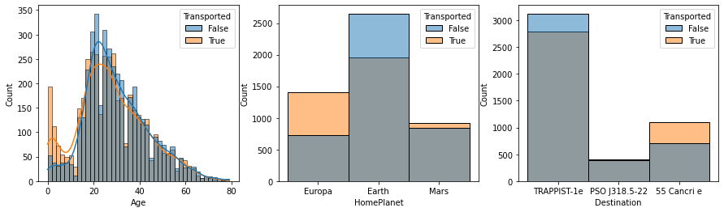

```python
pp.figure(figsize=(15,4))
pp.subplot(1,3,1)
sb.histplot(data=train_data, x='Age', kde=True, hue='Transported')

pp.subplot(1,3,2)
sb.histplot(data=train_data, x='HomePlanet', hue='Transported')

pp.subplot(1,3,3)
sb.histplot(data=train_data, x='Destination', hue='Transported')
```

## EXPLANATION OF THE VISUALIZATION ABOVE

### Age

1. From the age distribution, we can see that the ages of passengers in the spaceship ranges from 0-80 years old
2. Passengers within the age range 20-80 years were more/less likely to be transported

### Home Planet

1. Passengers from Earth were more than passengers from the other planets
2. Passengers from Earth were less likely to be Transported than not

### Destination

1. We can see that Passengers going to TRAPPIST-1e were more than the passengers going to PSO j318.5-22 and 55 Cancri e
2. Only 50% of Passengers going to PSO j318.5-22 were transported while th remaining 50% were not
3. From the plot, a lot of passengers going to TRAPPIST-1e were transported, likewise those going to 55 Cancri e

## FILLING THE MISSING VALUES

In this section, we fill the missing values in the data.

```python
train_data1=train_data.copy()
#AGE
train_data1['Age']=train_data1['Age'].interpolate()
train_data1['HomePlanet']=train_data1['HomePlanet'].fillna('Earth')
train_data1['Destination']=train_data1['Destination'].fillna('TRAPPIST-1e')
train_data1['Cabin']=train_data1['Cabin'].fillna('G/734/S')
train_data1['CryoSleep']=train_data1['CryoSleep'].fillna('False')
train_data1['VIP']=train_data1['VIP'].fillna('False')
train_data1['Name']=train_data1['Name'].fillna('Missing')

test_data1=test_data.copy()
test_data1['Age']=test_data1['Age'].interpolate(method='linear')
test_data1['HomePlanet']=test_data1['HomePlanet'].fillna('Earth')
test_data1['Destination']=test_data1['Destination'].fillna('TRAPPIST-1e')
test_data1['Cabin']=test_data1['Cabin'].fillna('G/160/P')
test_data1['CryoSleep']=test_data1['CryoSleep'].fillna('False')
test_data1['VIP']=test_data1['VIP'].fillna('False')
test_data1['Name']=test_data1['Name'].fillna('Missing')
```

```python
train_data1.isnull().sum()
```

```
PassengerId       0
HomePlanet        0
CryoSleep         0
Cabin             0
Destination       0
Age               0
VIP               0
RoomService     181
FoodCourt       183
ShoppingMall    208
Spa             183
VRDeck          188
Name              0
Transported       0
dtype: int64
```

## DROPPING THE NUMERICAL FEATURES EXCEPT AGE

Here we look at the data realistically to see which feature will determine if a passenger was transported or not. And from looking at the data, we can conclude that the expenditure features had no valid effect on a passenger being transported or not. So we drop the columns with these features.

```python
train_data2=train_data1.copy()
train_data2=train_data2.drop(['RoomService','FoodCourt','ShoppingMall','Spa','VRDeck'],axis=1)

test_data2=test_data1.copy()
test_data2=test_data2.drop(['RoomService','FoodCourt','ShoppingMall','Spa','VRDeck'],axis=1)
```

## PASSENGER ID AND CABIN FEATURES

Here we call the lambda function to get the Cabin Number, Cabin Deck, Cabin Side, Passenger Group and Passenger Number, as these features give quality predictions.

```python
train_data3=train_data2.copy()
#PASSENGER
train_data3['PassengerGroup']=train_data3['PassengerId'].apply(lambda x: x.split('_')[0]).astype(int)
train_data3['PassengerNo']=train_data3['PassengerId'].apply(lambda x: x.split('_')[1]).astype(int)
#CABIN
train_data3['CabinDeck']=train_data3['Cabin'].apply(lambda x: x.split('/')[0])
train_data3['CabinNo']=train_data3['Cabin'].apply(lambda x: x.split('/')[1]).astype(int)
train_data3['CabinSide']=train_data3['Cabin'].apply(lambda x: x.split('/')[2])


test_data3=test_data2.copy()
#PASSENGER
test_data3['PassengerGroup']=test_data3['PassengerId'].apply(lambda x: x.split('_')[0]).astype(int)
test_data3['PassengerNo']=test_data3['PassengerId'].apply(lambda x: x.split('_')[1]).astype(int)
#CABIN
test_data3['CabinDeck']=test_data3['Cabin'].apply(lambda x: x.split('/')[0])
test_data3['CabinNo']=test_data3['Cabin'].apply(lambda x: x.split('/')[1]).astype(int)
test_data3['CabinSide']=test_data3['Cabin'].apply(lambda x: x.split('/')[2])

#DROPPING PassengerId and Cabin COLUMNS

train_data3=train_data3.drop(['Cabin','Name'],axis=1)
test_data3=test_data3.drop(['Cabin','Name'],axis=1)
```

```python
train_data3
```

|  | PassengerId | HomePlanet | CryoSleep | Destination | Age | VIP | Transported | PassengerGroup | PassengerNo | CabinDeck | CabinNo | CabinSide |
| --- | --- | --- | --- | --- | --- | --- | --- | --- | --- | --- | --- | --- |
| 0 | 0001_01 | Europa | False | TRAPPIST-1e | 39.0 | False | False | 1 | 1 | B | 0 | P |
| 1 | 0002_01 | Earth | False | TRAPPIST-1e | 24.0 | False | True | 2 | 1 | F | 0 | S |
| 2 | 0003_01 | Europa | False | TRAPPIST-1e | 58.0 | True | False | 3 | 1 | A | 0 | S |
| 3 | 0003_02 | Europa | False | TRAPPIST-1e | 33.0 | False | False | 3 | 2 | A | 0 | S |
| 4 | 0004_01 | Earth | False | TRAPPIST-1e | 16.0 | False | True | 4 | 1 | F | 1 | S |
| ... | ... | ... | ... | ... | ... | ... | ... | ... | ... | ... | ... | ... |
| 8688 | 9276_01 | Europa | False | 55 Cancri e | 41.0 | True | False | 9276 | 1 | A | 98 | P |
| 8689 | 9278_01 | Earth | True | PSO J318.5-22 | 18.0 | False | False | 9278 | 1 | G | 1499 | S |
| 8690 | 9279_01 | Earth | False | TRAPPIST-1e | 26.0 | False | True | 9279 | 1 | G | 1500 | S |
| 8691 | 9280_01 | Europa | False | 55 Cancri e | 32.0 | False | False | 9280 | 1 | E | 608 | S |
| 8692 | 9280_02 | Europa | False | TRAPPIST-1e | 44.0 | False | True | 9280 | 2 | E | 608 | S |

8693 rows × 12 columns

## WORKING ON THE AGE (BINNING)

```python
#TRAIN DATA
train_data3['AgeClass']=train_data3['Age']
train_data3.loc[train_data3['AgeClass']<=12,'AgeClass']=0 #child
train_data3.loc[(train_data3['AgeClass']>12) & (train_data3['AgeClass']<=17),'AgeClass']=1 #teenager
train_data3.loc[(train_data3['AgeClass']>17) & (train_data3['AgeClass']<=30),'AgeClass']=2 #young adults
train_data3.loc[(train_data3['AgeClass']>30) & (train_data3['AgeClass']<=49),'AgeClass']=3 #middle-aged adults
train_data3.loc[(train_data3['AgeClass']>49) & (train_data3['AgeClass']<=80),'AgeClass']=4 #old adults

train_data3['AgeGroup']=train_data3['AgeClass']
train_data3['AgeRange']=train_data3['AgeClass']
train_data3['AgeRange'].replace([0.0,1.0,2.0,3.0,4.0],['under 13yrs','(13-17)yrs','(18-30)yrs','(31-49)yrs','(50-80)yrs'],inplace=True)
train_data3['AgeGroup'].replace([0.0,1.0,2.0,3.0,4.0],['Child','Teenager','Young Adult','Mid-Aged Adult','Old-Aged Adults'],inplace=True)
train_data3=train_data3.drop(['AgeClass'],axis=1)

#TEST DATA
test_data3['AgeClass']=test_data3['Age']
test_data3.loc[test_data3['AgeClass']<=12,'AgeClass']=0 #child
test_data3.loc[(test_data3['AgeClass']>12) & (test_data3['AgeClass']<=17),'AgeClass']=1 #teenager
test_data3.loc[(test_data3['AgeClass']>17) & (test_data3['AgeClass']<=30),'AgeClass']=2 #young adults
test_data3.loc[(test_data3['AgeClass']>30) & (test_data3['AgeClass']<=49),'AgeClass']=3 #middle-aged adults
test_data3.loc[(test_data3['AgeClass']>49) & (test_data3['AgeClass']<=80),'AgeClass']=4 #old adults

test_data3['AgeGroup']=test_data3['AgeClass']
test_data3['AgeRange']=test_data3['AgeClass']
test_data3['AgeRange'].replace([0.0,1.0,2.0,3.0,4.0],['under 13yrs','(13-17)yrs','(18-30)yrs','(31-49)yrs','(50-80)yrs'],inplace=True)
test_data3['AgeGroup'].replace([0.0,1.0,2.0,3.0,4.0],['Child','Teenager','Young Adult','Mid-Aged Adult','Old-Aged Adults'],inplace=True)
test_data3=test_data3.drop(['AgeClass'],axis=1)
```

```python
train_data3
```

|  | PassengerId | HomePlanet | CryoSleep | Destination | Age | VIP | Transported | PassengerGroup | PassengerNo | CabinDeck | CabinNo | CabinSide | AgeGroup | AgeRange |
| --- | --- | --- | --- | --- | --- | --- | --- | --- | --- | --- | --- | --- | --- | --- |
| 0 | 0001_01 | Europa | False | TRAPPIST-1e | 39.0 | False | False | 1 | 1 | B | 0 | P | Mid-Aged Adult | (31-49)yrs |
| 1 | 0002_01 | Earth | False | TRAPPIST-1e | 24.0 | False | True | 2 | 1 | F | 0 | S | Young Adult | (18-30)yrs |
| 2 | 0003_01 | Europa | False | TRAPPIST-1e | 58.0 | True | False | 3 | 1 | A | 0 | S | Old-Aged Adults | (50-80)yrs |
| 3 | 0003_02 | Europa | False | TRAPPIST-1e | 33.0 | False | False | 3 | 2 | A | 0 | S | Mid-Aged Adult | (31-49)yrs |
| 4 | 0004_01 | Earth | False | TRAPPIST-1e | 16.0 | False | True | 4 | 1 | F | 1 | S | Teenager | (13-17)yrs |
| ... | ... | ... | ... | ... | ... | ... | ... | ... | ... | ... | ... | ... | ... | ... |
| 8688 | 9276_01 | Europa | False | 55 Cancri e | 41.0 | True | False | 9276 | 1 | A | 98 | P | Mid-Aged Adult | (31-49)yrs |
| 8689 | 9278_01 | Earth | True | PSO J318.5-22 | 18.0 | False | False | 9278 | 1 | G | 1499 | S | Young Adult | (18-30)yrs |
| 8690 | 9279_01 | Earth | False | TRAPPIST-1e | 26.0 | False | True | 9279 | 1 | G | 1500 | S | Young Adult | (18-30)yrs |
| 8691 | 9280_01 | Europa | False | 55 Cancri e | 32.0 | False | False | 9280 | 1 | E | 608 | S | Mid-Aged Adult | (31-49)yrs |
| 8692 | 9280_02 | Europa | False | TRAPPIST-1e | 44.0 | False | True | 9280 | 2 | E | 608 | S | Mid-Aged Adult | (31-49)yrs |

8693 rows × 14 columns

## NEW DATA VISUALISATION

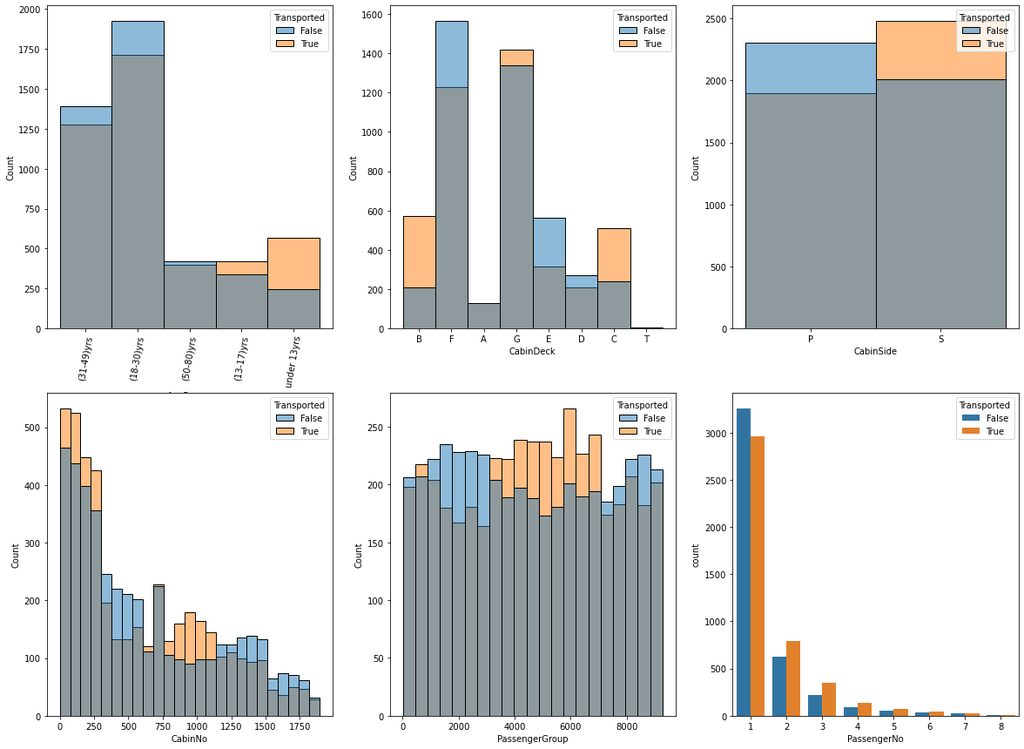

```python
pp.figure(figsize=(20,15))
pp.subplot(2,3,1)
sb.histplot(data=train_data3, x='AgeRange',hue='Transported')
pp.xticks(rotation=80)

pp.subplot(2,3,2)
sb.histplot(data=train_data3, x='CabinDeck', hue='Transported')

pp.subplot(2,3,3)
sb.histplot(data=train_data3, x='CabinSide', hue='Transported')

pp.subplot(2,3,4)
sb.histplot(data=train_data3, x='CabinNo',hue='Transported')

pp.subplot(2,3,5)
sb.histplot(data=train_data3, x='PassengerGroup', hue='Transported')

pp.subplot(2,3,6)
sb.countplot(data=train_data3, x='PassengerNo', hue='Transported')
```

## MODELLING

We will begin this by dropping some columns

```python
train_data4=train_data3.copy()
train_data4=train_data4.drop(['PassengerId','PassengerGroup','CabinNo','AgeRange','Age'],axis=1)
test_data4=test_data3.copy()
test_data4=test_data4.drop(['PassengerId','PassengerGroup','CabinNo','AgeRange','Age'],axis=1)
```

```python
train_data4.info()
```

```
<class 'pandas.core.frame.DataFrame'>
RangeIndex: 8693 entries, 0 to 8692
Data columns (total 9 columns):
 #   Column       Non-Null Count  Dtype
---  ------       --------------  -----
 0   HomePlanet   8693 non-null   object
 1   CryoSleep    8693 non-null   object
 2   Destination  8693 non-null   object
 3   VIP          8693 non-null   object
 4   Transported  8693 non-null   bool
 5   PassengerNo  8693 non-null   int32
 6   CabinDeck    8693 non-null   object
 7   CabinSide    8693 non-null   object
 8   AgeGroup     8693 non-null   object
dtypes: bool(1), int32(1), object(7)
memory usage: 518.0+ KB
```

### LABEL ENCODING

```python
from sklearn.preprocessing import LabelEncoder as LE
#TRAIN DATA
train_data5=train_data4.copy()
train_data5['HomePlanet']=LE().fit_transform(train_data5['HomePlanet'])
train_data5['CryoSleep'].replace([False,True],[0,1],inplace=True)
train_data5['Destination']=LE().fit_transform(train_data5['Destination'])
train_data5['VIP'].replace([False,True],[0,1],inplace=True)
train_data5['CabinDeck']=LE().fit_transform(train_data5['CabinDeck'])
train_data5['CabinSide']=LE().fit_transform(train_data5['CabinSide'])
train_data5['AgeGroup']=LE().fit_transform(train_data5['AgeGroup'])
train_data5['Transported'].replace([False,True],[0,1],inplace=True)

#TEST DATA
test_data5=test_data4.copy()
test_data5['HomePlanet']=LE().fit_transform(test_data5['HomePlanet'])
test_data5['CryoSleep'].replace([False,True],[0,1],inplace=True)
test_data5['Destination']=LE().fit_transform(test_data5['Destination'])
test_data5['VIP'].replace([False,True],[0,1],inplace=True)
test_data5['CabinDeck']=LE().fit_transform(test_data5['CabinDeck'])
test_data5['CabinSide']=LE().fit_transform(test_data5['CabinSide'])
test_data5['AgeGroup']=LE().fit_transform(test_data5['HomePlanet'])
```

```python
test_data5
```

|  | HomePlanet | CryoSleep | Destination | VIP | PassengerNo | CabinDeck | CabinSide | AgeGroup |
| --- | --- | --- | --- | --- | --- | --- | --- | --- |
| 0 | 0 | 1 | 2 | 0 | 1 | 6 | 1 | 0 |
| 1 | 0 | 0 | 2 | 0 | 1 | 5 | 1 | 0 |
| 2 | 1 | 1 | 0 | 0 | 1 | 2 | 1 | 1 |
| 3 | 1 | 0 | 2 | 0 | 1 | 2 | 1 | 1 |
| 4 | 0 | 0 | 2 | 0 | 1 | 5 | 1 | 0 |
| ... | ... | ... | ... | ... | ... | ... | ... | ... |
| 4272 | 0 | 1 | 2 | 0 | 2 | 6 | 1 | 0 |
| 4273 | 0 | 0 | 2 | 0 | 1 | 6 | 0 | 0 |
| 4274 | 2 | 1 | 0 | 0 | 1 | 3 | 0 | 2 |
| 4275 | 1 | 0 | 2 | 0 | 1 | 3 | 0 | 1 |
| 4276 | 0 | 1 | 1 | 0 | 1 | 6 | 1 | 0 |

4277 rows × 8 columns

```python
train_data5.info()
```

```
<class 'pandas.core.frame.DataFrame'>
RangeIndex: 8693 entries, 0 to 8692
Data columns (total 9 columns):
 #   Column       Non-Null Count  Dtype
---  ------       --------------  -----
 0   HomePlanet   8693 non-null   int32
 1   CryoSleep    8693 non-null   object
 2   Destination  8693 non-null   int32
 3   VIP          8693 non-null   object
 4   Transported  8693 non-null   int64
 5   PassengerNo  8693 non-null   int32
 6   CabinDeck    8693 non-null   int32
 7   CabinSide    8693 non-null   int32
 8   AgeGroup     8693 non-null   int32
dtypes: int32(6), int64(1), object(2)
memory usage: 407.6+ KB
```

### CONVERTING OBJECT TO FLOAT

I really do not know why after label encoding of some features I got an error, so here we will convert strings/bool to float to terminate that error.

```python
train_data5['CryoSleep']=pd.to_numeric(train_data5['CryoSleep'],errors='coerce')
train_data5['VIP']=pd.to_numeric(train_data5['VIP'],errors='coerce')
train_data5.fillna(0,inplace=True)

test_data5['CryoSleep']=pd.to_numeric(test_data5['CryoSleep'],errors='coerce')
test_data5['VIP']=pd.to_numeric(test_data5['VIP'],errors='coerce')
test_data5.fillna(0,inplace=True)
```

### X_TRAIN,X_TEST,Y_TRAIN,Y_TEST

The data has already been splitted into the train and test data. What is left is for us to assign them to their respective x_train,y_train,x_test and y_test. Oh! and for y_test, we will have to predict that as we only have x_test from the test data.

```python
x_train=train_data5.iloc[:,[0,1,2,3,5,6,7,8]].values
y_train=train_data5.iloc[:,4].values
x_test=test_data5.iloc[:,[0,1,2,3,4,5,6,7]].values
```

```python
x_train
```

```
array([[1., 0., 2., ..., 1., 0., 1.],
       [0., 0., 2., ..., 5., 1., 4.],
       [1., 0., 2., ..., 0., 1., 2.],
       ...,
       [0., 0., 2., ..., 6., 1., 4.],
       [1., 0., 0., ..., 4., 1., 1.],
       [1., 0., 2., ..., 4., 1., 1.]])
```

```python
y_train
```

```
array([0, 1, 0, ..., 1, 0, 1], dtype=int64)
```

```python
x_test
```

```
array([[0., 1., 2., ..., 6., 1., 0.],
       [0., 0., 2., ..., 5., 1., 0.],
       [1., 1., 0., ..., 2., 1., 1.],
       ...,
       [2., 1., 0., ..., 3., 0., 2.],
       [1., 0., 2., ..., 3., 0., 1.],
       [0., 1., 1., ..., 6., 1., 0.]])
```

### MODEL ALGORITHMS

Here we will try out different classification models and see which one predicts best.

```python
#LOGISTIC REGRESSION
from sklearn.linear_model import LogisticRegression
model1=LogisticRegression(C=0.01, penalty= 'l2',random_state=22).fit(x_train,y_train)
accuracy_score1=model1.score(x_train,y_train)
prediction1=model1.predict(x_test)

#DECISION TREE CLASSIFIER
from sklearn.tree import DecisionTreeClassifier
model2=DecisionTreeClassifier(criterion= 'gini', max_depth= 5, min_samples_leaf= 2, min_samples_split= 3, splitter= 'best',random_state=22).fit(x_train,y_train)
accuracy_score2=model2.score(x_train,y_train)
prediction2=model2.predict(x_test)

#RANDOM FOREST CLASSIFIER
from sklearn.ensemble import RandomForestClassifier
model3=RandomForestClassifier(n_estimators=100,criterion='entropy',random_state=22).fit(x_train,y_train)
accuracy_score3=model3.score(x_train,y_train)
prediction3=model3.predict(x_test)

#SVC
from sklearn.svm import SVC
model4=SVC(C= 100, kernel= 'poly',degree=2,random_state=22).fit(x_train,y_train)
accuracy_score4=model4.score(x_train,y_train)
prediction4=model4.predict(x_test)

#GRADIENT BOOSTING CLASSIFIER
from sklearn.ensemble import GradientBoostingClassifier
model5=GradientBoostingClassifier().fit(x_train,y_train)
accuracy_score5=model5.score(x_train,y_train)
prediction5=model5.predict(x_test)

#XGBCLASSIFIER
from xgboost import XGBClassifier
model6=XGBClassifier(eval_metric='logloss').fit(x_train,y_train)
accuracy_score6=model6.score(x_train,y_train)
prediction6=model6.predict(x_test)
```

## HEATMAP

This will check the number of times the models predicted the train data correctly, where True = 1 and False = 0

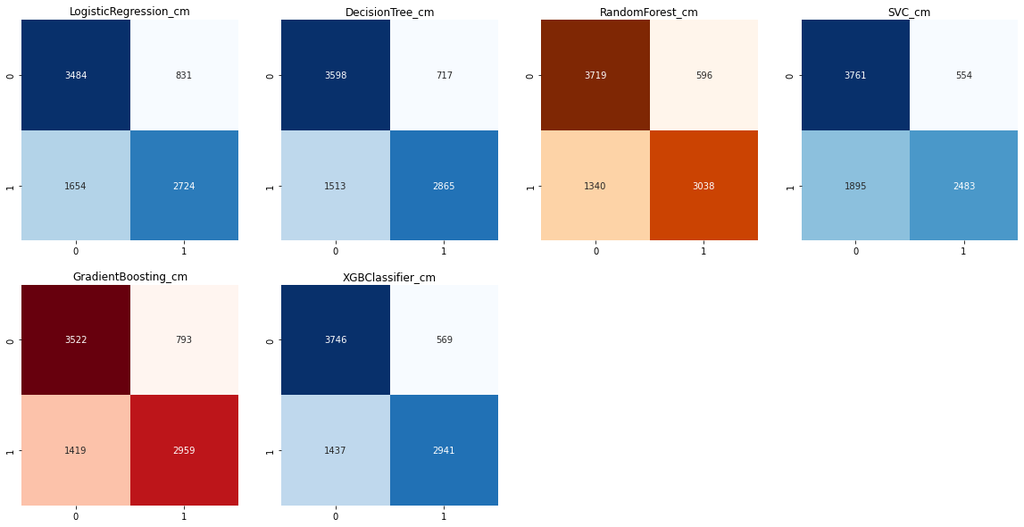

```python
from sklearn.metrics import confusion_matrix

pred1=model1.predict(x_train)
model1_cm=confusion_matrix(y_train,pred1)
pred2=model2.predict(x_train)
model2_cm=confusion_matrix(y_train,pred2)
pred3=model3.predict(x_train)
model3_cm=confusion_matrix(y_train,pred3)
pred4=model4.predict(x_train)
model4_cm=confusion_matrix(y_train,pred4)
pred5=model5.predict(x_train)
model5_cm=confusion_matrix(y_train,pred5)
pred6=model6.predict(x_train)
model6_cm=confusion_matrix(y_train,pred6)

#HEATMAP PLOT
pp.figure(figsize=(20,10))

pp.subplot(2,4,1)
pp.title("LogisticRegression_cm")
sb.heatmap(model1_cm,annot=True,cmap="Blues",fmt="d",cbar=False)

pp.subplot(2,4,2)
pp.title("DecisionTree_cm")
sb.heatmap(model2_cm,annot=True,cmap="Blues",fmt="d",cbar=False)

pp.subplot(2,4,3)
pp.title("RandomForest_cm")
sb.heatmap(model3_cm,annot=True,cmap="Oranges",fmt="d",cbar=False)

pp.subplot(2,4,4)
pp.title("SVC_cm")
sb.heatmap(model4_cm,annot=True,cmap="Blues",fmt="d",cbar=False)

pp.subplot(2,4,5)
pp.title("GradientBoosting_cm")
sb.heatmap(model5_cm,annot=True,cmap="Reds",fmt="d",cbar=False)

pp.subplot(2,4,6)
pp.title("XGBClassifier_cm")
sb.heatmap(model6_cm,annot=True,cmap="Blues",fmt="d",cbar=False)
```

## DATAFRAME OF THE MODELS

```python
model_accuracy=pd.DataFrame({
    'Algorithm':['LogisticRegression','DecisionTreeClassifier','RandomForestClassifier','SVC','GradientBoostingClassifier','XGBClassifier'],
    'Train Score':[accuracy_score1,accuracy_score2,accuracy_score3,accuracy_score4,accuracy_score5,accuracy_score6]
})
model_accuracy
```

|  | Algorithm | Train Score |
| --- | --- | --- |
| 0 | LogisticRegression | 0.714138 |
| 1 | DecisionTreeClassifier | 0.743472 |
| 2 | RandomForestClassifier | 0.777292 |
| 3 | SVC | 0.718279 |
| 4 | GradientBoostingClassifier | 0.745542 |
| 5 | XGBClassifier | 0.769240 |

## SUBMISSION

```python
submission_data=pd.read_csv('sample_submission.csv')
submission_data['Transported']=prediction3
# I made use of prediction3 from model3 (RandomForestClassifier) because it had the highest accuracy score. more hyperparameter tuning would have increased the score or maybe using other classifiers or tensorflow
submission_data.replace([0,1],[False,True],inplace=True)
submission_data.to_csv('submission.csv',index=False)
```

```python
submission_data
```

|  | PassengerId | Transported |
| --- | --- | --- |
| 0 | 0013_01 | True |
| 1 | 0018_01 | True |
| 2 | 0019_01 | True |
| 3 | 0021_01 | True |
| 4 | 0023_01 | True |
| ... | ... | ... |
| 4272 | 9266_02 | True |
| 4273 | 9269_01 | False |
| 4274 | 9271_01 | True |
| 4275 | 9273_01 | False |
| 4276 | 9277_01 | True |

4277 rows × 2 columns

This brings us to the end of this notebook. I hope it was well detailed enough. Please leave a comment as it will help me improve on areas were I should. Thanks you :)